# Tugas Praktikum: Pemodelan Regresi Deret Waktu

Autokorelasi Sisaan (Plot Sisaan & Durbin-Watson) dan Penanganannya (Cochrane-Orcutt)

Muhammad Shira Pramudita - M0401241094

02 September 2026

# 1 Pendahuluan

Laporan ini melakukan **pemodelan regresi deret waktu** terhadap dua gugus data:

1. **Market Share terhadap Price** (20 periode)
2. **Sales terhadap Advertising** (tahun 1975–2014, 40 observasi)

Untuk setiap model, dilakukan:

- Pendugaan model regresi linear sederhana (OLS)
- Pemeriksaan autokorelasi sisaan melalui **plot sisaan** dan **uji Durbin-Watson**
- Jika terdapat autokorelasi, dilakukan penanganan dengan **metode Cochrane-Orcutt**

# 2 Fungsi Cochrane-Orcutt (Manual, Iteratif)

Metode Cochrane-Orcutt menduga koefisien autokorelasi $\rho$ dari sisaan OLS, lalu mentransformasi data:

$$Y_t^* = Y_t - \rho Y_{t-1} \qquad X_t^*
= X_t - \rho X_{t-1}$$

kemudian meregresikan $Y_t^*$ terhadap $X_t^*$. Proses ini diulang (iteratif) hingga $\rho$ konvergen.

```r
cochrane_orcutt <- function(y, x, tol = 1e-6, max_iter = 50) {
  n <- length(y)
  rho <- 0
  for (iter in 1:max_iter) {
    y_star <- y[2:n] - rho * y[1:(n - 1)]
    x_star <- x[2:n] - rho * x[1:(n - 1)]
    fit_star <- lm(y_star ~ x_star)
    b0_star <- coef(fit_star)[1]
    b1_star <- coef(fit_star)[2]
    b0 <- b0_star / (1 - rho)
    b1 <- b1_star

    resid_orig <- y - (b0 + b1 * x)
    rho_new <- sum(resid_orig[2:n] * resid_orig[1:(n - 1)]) /
      sum(resid_orig[1:(n - 1)]^2)

    if (abs(rho_new - rho) < tol) {
      rho <- rho_new
      break
    }
    rho <- rho_new
  }
  list(rho = rho, b0 = b0, b1 = b1, iterations = iter,
       fit_star = fit_star, y_star = y_star, x_star = x_star)
}
```

# 3 Dataset 1: Market Share vs Price

## 3.1 Data

```r
data1 <- data.frame(
  Period = 1:20,
  MarketShare = c(3.63, 4.20, 3.33, 4.54, 2.89, 4.87, 4.90, 5.29, 6.18, 7.20,
                  7.25, 6.09, 6.80, 8.65, 8.43, 8.29, 7.18, 7.90, 8.45, 8.23),
  Price = c(0.97, 0.95, 0.99, 0.91, 0.98, 0.90, 0.89, 0.86, 0.85, 0.82,
            0.79, 0.83, 0.81, 0.77, 0.76, 0.80, 0.83, 0.79, 0.76, 0.78)
)
data1
```

| Period | MarketShare | Price |
| --- | --- | --- |
| 1 | 3.63 | 0.97 |
| 2 | 4.20 | 0.95 |
| 3 | 3.33 | 0.99 |
| 4 | 4.54 | 0.91 |
| 5 | 2.89 | 0.98 |
| 6 | 4.87 | 0.90 |
| 7 | 4.90 | 0.89 |
| 8 | 5.29 | 0.86 |
| 9 | 6.18 | 0.85 |
| 10 | 7.20 | 0.82 |

[output cut: 10 more lines]

## 3.2 Model Regresi Awal (OLS)

```r
fit1 <- lm(MarketShare ~ Price, data = data1)
summary(fit1)
```

```
##
## Call:
## lm(formula = MarketShare ~ Price, data = data1)
##
## Residuals:
##      Min       1Q   Median       3Q      Max
## -0.73068 -0.29764 -0.00966  0.30224  0.81193
##
## Coefficients:
##             Estimate Std. Error t value Pr(>|t|)
## (Intercept)   26.910      1.110   24.25 3.39e-15 ***
## Price        -24.290      1.298  -18.72 3.02e-13 ***
## ---
## Signif. codes:  0 '***' 0.001 '**' 0.01 '*' 0.05 '.' 0.1 ' ' 1
##
## Residual standard error: 0.4287 on 18 degrees of freedom
## Multiple R-squared:  0.9511, Adjusted R-squared:  0.9484
## F-statistic: 350.3 on 1 and 18 DF,  p-value: 3.019e-13
```

Model dugaan: **MarketShare = 26.91 + (-24.29) x Price**

## 3.3 Pemeriksaan Autokorelasi Sisaan

### 3.3.1 Plot Sisaan

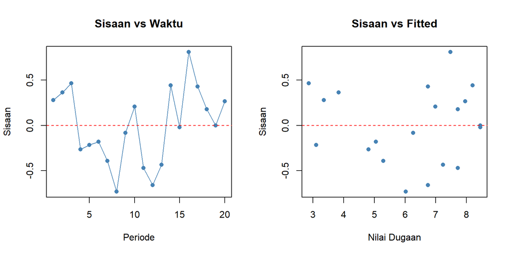

```r
par(mfrow = c(1, 2))
plot(data1$Period, resid(fit1), type = "o", pch = 16, col = "steelblue",
     xlab = "Periode", ylab = "Sisaan", main = "Sisaan vs Waktu")
abline(h = 0, col = "red", lty = 2)
plot(fitted(fit1), resid(fit1), pch = 16, col = "steelblue",
     xlab = "Nilai Dugaan", ylab = "Sisaan", main = "Sisaan vs Fitted")
abline(h = 0, col = "red", lty = 2)
```

Plot sisaan terhadap waktu menunjukkan pola bergelombang (tidak acak di sekitar nol) — indikasi awal adanya autokorelasi.

### 3.3.2 Uji Durbin-Watson

```r
dw1 <- dwtest(fit1)
dw1
```

```
##
##  Durbin-Watson test
##
## data:  fit1
## DW = 1.1358, p-value = 0.009813
## alternative hypothesis: true autocorrelation is greater than 0
```

Karena **p-value < 0.05**, maka **tolak H0** -> terdapat autokorelasi positif pada sisaan.

## 3.4 Penanganan Autokorelasi: Cochrane-Orcutt

```r
co1 <- cochrane_orcutt(data1$MarketShare, data1$Price)
cat("Rho terestimasi   :", round(co1$rho, 5), "\n")
```

```
## Rho terestimasi   : 0.42523
```

```r
cat("Jumlah iterasi     :", co1$iterations, "\n")
```

```
## Jumlah iterasi     : 7
```

```r
cat("Intercept baru (b0):", round(co1$b0, 5), "\n")
```

```
## Intercept baru (b0): 26.72209
```

```r
cat("Slope baru (b1)    :", round(co1$b1, 5), "\n")
```

```
## Slope baru (b1)    : -24.08413
```

```r
summary(co1$fit_star)
```

```
##
## Call:
## lm(formula = y_star ~ x_star)
##
## Residuals:
##      Min       1Q   Median       3Q      Max
## -0.55508 -0.25069 -0.05506  0.25007  0.83017
##
## Coefficients:
##             Estimate Std. Error t value Pr(>|t|)
## (Intercept)  15.3590     0.9385   16.36 7.71e-12 ***
## x_star      -24.0841     1.9385  -12.42 5.90e-10 ***
## ---
## Signif. codes:  0 '***' 0.001 '**' 0.01 '*' 0.05 '.' 0.1 ' ' 1
##
## Residual standard error: 0.3955 on 17 degrees of freedom
## Multiple R-squared:  0.9008, Adjusted R-squared:  0.895
## F-statistic: 154.4 on 1 and 17 DF,  p-value: 5.903e-10
```

Model setelah koreksi: **MarketShare = 26.722 + (-24.084) x Price**, dengan $\rho$ = 0.4252.

### 3.4.1 Plot Sisaan Setelah Koreksi

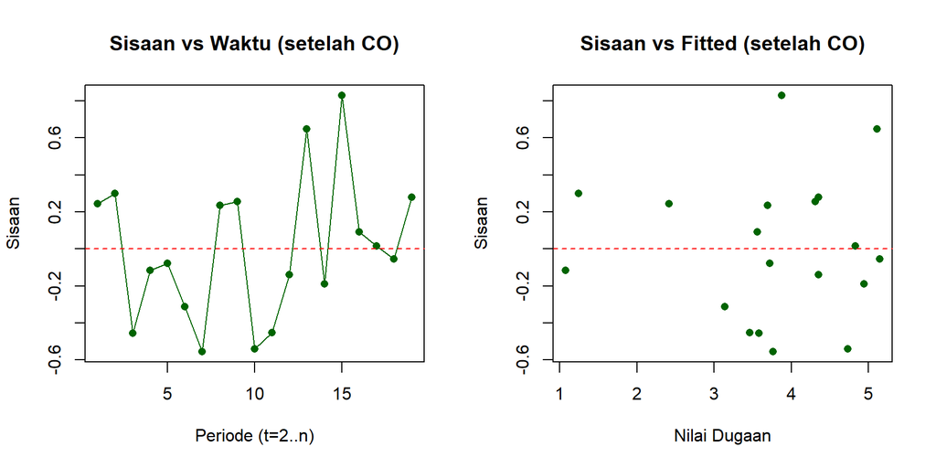

```r
par(mfrow = c(1, 2))
plot(seq_along(co1$y_star), resid(co1$fit_star), type = "o", pch = 16, col = "darkgreen",
     xlab = "Periode (t=2..n)", ylab = "Sisaan", main = "Sisaan vs Waktu (setelah CO)")
abline(h = 0, col = "red", lty = 2)
plot(fitted(co1$fit_star), resid(co1$fit_star), pch = 16, col = "darkgreen",
     xlab = "Nilai Dugaan", ylab = "Sisaan", main = "Sisaan vs Fitted (setelah CO)")
abline(h = 0, col = "red", lty = 2)
```

### 3.4.2 Uji Durbin-Watson Setelah Koreksi

```r
dw1_co <- dwtest(co1$fit_star)
dw1_co
```

```
##
##  Durbin-Watson test
##
## data:  co1$fit_star
## DW = 1.958, p-value = 0.4151
## alternative hypothesis: true autocorrelation is greater than 0
```

**Autokorelasi sisaan sudah teratasi** setelah koreksi Cochrane-Orcutt.

# 4 Dataset 2: Sales vs Advertising

## 4.1 Data

```r
data2 <- data.frame(
  Year = 1975:2014,
  Sales = c(11.7, 12.0, 12.3, 12.8, 13.1, 13.6, 13.9, 14.4, 14.7, 15.3,
            15.5, 15.8, 16.1, 16.6, 16.9, 16.7, 16.9, 17.4, 17.6, 17.9,
            18.0, 17.9, 18.0, 18.2, 18.2, 18.3, 18.6, 19.2, 19.3, 19.5,
            19.2, 19.3, 19.5, 20.0, 20.0, 19.9, 19.8, 19.9, 20.2, 21.0),
  Advertising = c(9.4, 9.6, 10, 10.4, 10.8, 10.9, 11.7, 12.2, 12.5, 12.9,
                  13.0, 13.2, 13.8, 14.2, 14.6, 14.4, 15.0, 15.4, 15.7, 15.9,
                  15.9, 16.0, 16.3, 16.2, 16.8, 17.3, 17.6, 18.1, 18.3, 18.5,
                  18.7, 18.9, 19.2, 20.0, 20.0, 20.3, 20.4, 21.0, 21.5, 22.1)
)
data2
```

| Year | Sales | Advertising |
| --- | --- | --- |
| 1975 | 11.7 | 9.4 |
| 1976 | 12.0 | 9.6 |
| 1977 | 12.3 | 10.0 |
| 1978 | 12.8 | 10.4 |
| 1979 | 13.1 | 10.8 |
| 1980 | 13.6 | 10.9 |
| 1981 | 13.9 | 11.7 |
| 1982 | 14.4 | 12.2 |
| 1983 | 14.7 | 12.5 |
| 1984 | 15.3 | 12.9 |

[output cut: 30 more lines]

## 4.2 Model Regresi Awal (OLS)

```r
fit2 <- lm(Sales ~ Advertising, data = data2)
summary(fit2)
```

```
##
## Call:
## lm(formula = Sales ~ Advertising, data = data2)
##
## Residuals:
##      Min       1Q   Median       3Q      Max
## -1.03758 -0.40343  0.08933  0.45674  0.74036
##
## Coefficients:
##             Estimate Std. Error t value Pr(>|t|)
## (Intercept)  5.96513    0.38092   15.66   <2e-16 ***
## Advertising  0.71035    0.02365   30.04   <2e-16 ***
## ---
## Signif. codes:  0 '***' 0.001 '**' 0.01 '*' 0.05 '.' 0.1 ' ' 1
##
## Residual standard error: 0.527 on 38 degrees of freedom
## Multiple R-squared:  0.9596, Adjusted R-squared:  0.9585
## F-statistic: 902.3 on 1 and 38 DF,  p-value: < 2.2e-16
```

Model dugaan: **Sales = 5.965 + (0.71) x Advertising**

## 4.3 Pemeriksaan Autokorelasi Sisaan

### 4.3.1 Plot Sisaan

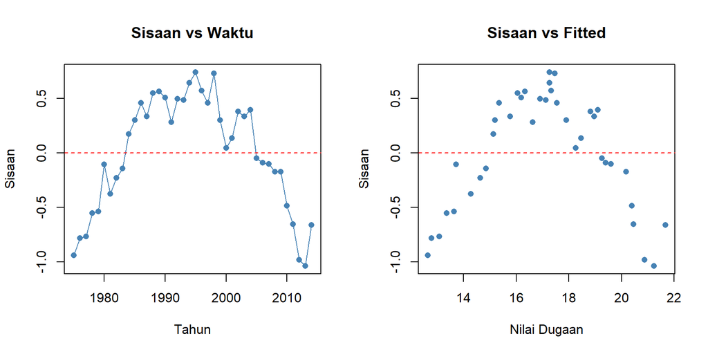

```r
par(mfrow = c(1, 2))
plot(data2$Year, resid(fit2), type = "o", pch = 16, col = "steelblue",
     xlab = "Tahun", ylab = "Sisaan", main = "Sisaan vs Waktu")
abline(h = 0, col = "red", lty = 2)
plot(fitted(fit2), resid(fit2), pch = 16, col = "steelblue",
     xlab = "Nilai Dugaan", ylab = "Sisaan", main = "Sisaan vs Fitted")
abline(h = 0, col = "red", lty = 2)
```

Sisaan bergerak sangat mulus (naik-turun berkelanjutan, bukan acak) — indikasi kuat adanya autokorelasi positif, wajar karena data tahunan yang trending.

### 4.3.2 Uji Durbin-Watson

```r
dw2 <- dwtest(fit2)
dw2
```

```
##
##  Durbin-Watson test
##
## data:  fit2
## DW = 0.16204, p-value < 2.2e-16
## alternative hypothesis: true autocorrelation is greater than 0
```

Karena **p-value < 0.05**, maka **tolak H0** -> terdapat autokorelasi positif pada sisaan.

## 4.4 Penanganan Autokorelasi: Cochrane-Orcutt

```r
co2 <- cochrane_orcutt(data2$Sales, data2$Advertising)
cat("Rho terestimasi   :", round(co2$rho, 5), "\n")
```

```
## Rho terestimasi   : 0.90312
```

```r
cat("Jumlah iterasi     :", co2$iterations, "\n")
```

```
## Jumlah iterasi     : 27
```

```r
cat("Intercept baru (b0):", round(co2$b0, 5), "\n")
```

```
## Intercept baru (b0): 10.25226
```

```r
cat("Slope baru (b1)    :", round(co2$b1, 5), "\n")
```

```
## Slope baru (b1)    : 0.48849
```

```r
summary(co2$fit_star)
```

```
##
## Call:
## lm(formula = y_star ~ x_star)
##
## Residuals:
##      Min       1Q   Median       3Q      Max
## -0.37730 -0.14957  0.01257  0.10464  0.45315
##
## Coefficients:
##             Estimate Std. Error t value Pr(>|t|)
## (Intercept)  0.99323    0.14141   7.024 2.64e-08 ***
## x_star       0.48849    0.07542   6.477 1.43e-07 ***
## ---
## Signif. codes:  0 '***' 0.001 '**' 0.01 '*' 0.05 '.' 0.1 ' ' 1
##
## Residual standard error: 0.1868 on 37 degrees of freedom
## Multiple R-squared:  0.5313, Adjusted R-squared:  0.5187
## F-statistic: 41.95 on 1 and 37 DF,  p-value: 1.426e-07
```

Model setelah koreksi: **Sales = 10.252 + (0.488) x Advertising**, dengan $\rho$ = 0.9031.

### 4.4.1 Plot Sisaan Setelah Koreksi

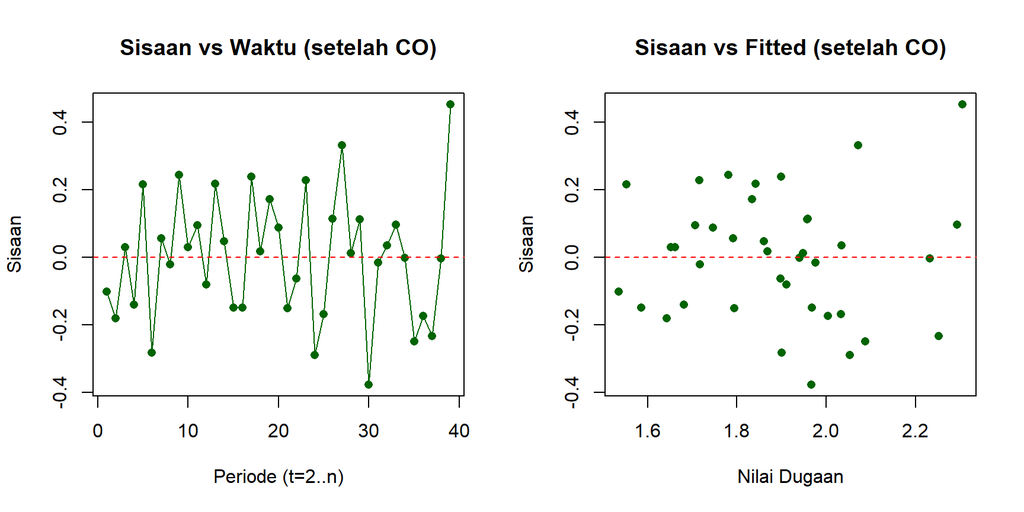

```r
par(mfrow = c(1, 2))
plot(seq_along(co2$y_star), resid(co2$fit_star), type = "o", pch = 16, col = "darkgreen",
     xlab = "Periode (t=2..n)", ylab = "Sisaan", main = "Sisaan vs Waktu (setelah CO)")
abline(h = 0, col = "red", lty = 2)
plot(fitted(co2$fit_star), resid(co2$fit_star), pch = 16, col = "darkgreen",
     xlab = "Nilai Dugaan", ylab = "Sisaan", main = "Sisaan vs Fitted (setelah CO)")
abline(h = 0, col = "red", lty = 2)
```

### 4.4.2 Uji Durbin-Watson Setelah Koreksi

```r
dw2_co <- dwtest(co2$fit_star)
dw2_co
```

```
##
##  Durbin-Watson test
##
## data:  co2$fit_star
## DW = 1.9393, p-value = 0.378
## alternative hypothesis: true autocorrelation is greater than 0
```

**Autokorelasi sisaan sudah teratasi** setelah koreksi Cochrane-Orcutt.

# 5 Kesimpulan

### 5.0.1 Market Share vs Price

- Model awal: DW = 1.136, p-value = 0.009813 -> **ada autokorelasi**.
- Setelah Cochrane-Orcutt ($\rho$ = 0.4252): DW = 1.958, p-value = 0.4151 -> **autokorelasi teratasi**.
- Model akhir: Y = 26.722 + (-24.084) x X

### 5.0.2 Sales vs Advertising

- Model awal: DW = 0.162, p-value = < 2.2e-16 -> **ada autokorelasi**.
- Setelah Cochrane-Orcutt ($\rho$ = 0.9031): DW = 1.939, p-value = 0.378 -> **autokorelasi teratasi**.
- Model akhir: Y = 10.252 + (0.488) x X

Pada kedua model regresi deret waktu, sisaan dari model OLS awal menunjukkan **autokorelasi positif yang signifikan** (dikonfirmasi baik dari plot sisaan yang berpola maupun uji Durbin-Watson dengan p-value < 0.05). Setelah dilakukan penanganan dengan **metode Cochrane-Orcutt**, autokorelasi pada sisaan berhasil diatasi (uji Durbin-Watson pada model transformasi menghasilkan p-value > 0.05), sehingga model hasil transformasi ini yang direkomendasikan untuk digunakan sebagai model akhir.